# Investigating the Role of TTBK2 on Cilia Formation

Kavya Raghunathan

October 1, 2021

# Background

The Goetz Lab studies primary cilia, cellular organelles that play an important role in cellular-signaling and protein trafficking via various developmental pathways. Sarah identified TTBK2 (tau-tubulin kinase 2), a kinase that is essential for initial stages of cilia assembly: removing negative regulators of cilia and recruiting intraflagellar transport proteins that assemble the cilia.

There is a lack of information regarding the role TTBK2 plays in Purkinje cells (found primarily in the cerebellum) development and cilia formation. Therefore, P0 and P32 cerebellum from Wild Type and TTBK2 Knockouts (TTBK2 KO) mice were dissected, sectioned, and stained for Calbindin and Arl13b, markers for Purkinje cells and cilia, respectively.

## Main Dataset

To begin, I imported my datasets for both time points (P0 and P32): each data point represents one image and contains the folia imaged, mouse genotype, number of Purkinje cells in the image, and number of ciliated cells in the image (= number of cilia).

```r
head(final_dataset)
```

```
## # A tibble: 6 × 6
##   image_id folia genotype_id genotype                           num_pn num_cilia
##   <chr>    <chr> <chr>       <chr>                               <dbl>     <dbl>
## 1 32.3.II  I/II  Mutant 1    TTBK2 fl/fl;Ptf1a-Cre (+) (mutant)     53         1
## 2 32.3.III III   Mutant 1    TTBK2 fl/fl;Ptf1a-Cre (+)              10         0
## 3 32.3.VI  VI    Mutant 1    TTBK2 fl/fl;Ptf1a-Cre (+)              19         0
## 4 32.3.IX  IX    Mutant 1    TTBK2 fl/fl;Ptf1a-Cre (+)              22         7
## 5 34.II    I/II  Wild Type 1 TTBK2 fl/+;Ptf1a-Cre (-) WT            37        25
## 6 34.III   III   Wild Type 1 TTBK2 fl/+;Ptf1a-Cre (-)               21        17
```

```r
head(p0_dataset)
```

```
## # A tibble: 6 × 6
##   image_id folia genotype_id genotype                 num_pn num_cilia
##   <chr>    <chr> <chr>       <chr>                     <dbl>     <dbl>
## 1 9.1.1    I/II  Wild Type 1 TTBK2 fl/+;Ptf1a-Cre (+)     92        70
## 2 9.1.3    III   Wild Type 1 TTBK2 fl/+;Ptf1a-Cre (+)     81        53
## 3 9.1.8    VIII  Wild Type 1 TTBK2 fl/+;Ptf1a-Cre (+)     63        45
## 4 9.1.10   IX    Wild Type 1 TTBK2 fl/+;Ptf1a-Cre (+)    113        57
## 5 9.i.a    I/II  Wild Type 1 TTBK2 fl/+;Ptf1a-Cre (+)     86        42
## 6 9.iii.a  III   Wild Type 1 TTBK2 fl/+;Ptf1a-Cre (+)     60        38
```

### Cilia Frequency by Age

I combined these two data sets together to easily compare cilia frequency.

```r
#combine the two to plot
compare_p0p32_frequency <- compare_p32_cilia_frequency%>%
  bind_rows(compare_p0_cilia_frequency)
head(compare_p0p32_frequency)
```

```
## # A tibble: 6 × 9
##   image_id folia genotype_id genotype  num_pn num_cilia cilia_frequency Genotype
##   <chr>    <chr> <chr>       <chr>      <dbl>     <dbl>           <dbl> <chr>
## 1 34.II    I/II  Wild Type 1 TTBK2 fl…     37        25            67.6 Wild Ty…
## 2 34.III   III   Wild Type 1 TTBK2 fl…     21        17            81.0 Wild Ty…
## 3 34.VI    VI    Wild Type 1 TTBK2 fl…     41        30            73.2 Wild Ty…
## 4 34.IX    IX    Wild Type 1 TTBK2 fl…     33        13            39.4 Wild Ty…
## 5 23.II    I/II  Wild Type 2 TTBK2 fl…     36        30            83.3 Wild Ty…
## 6 23.III   III   Wild Type 2 TTBK2 fl…     30        20            66.7 Wild Ty…
## # … with 1 more variable: Age <chr>
```

And finally created a grouped barplot. It’s pretty clear that cilia frequency is greatly reduced in TTBK2 KO compared to WT, and while cilia frequency increases over time in WT conditions, it decreases in the KO.

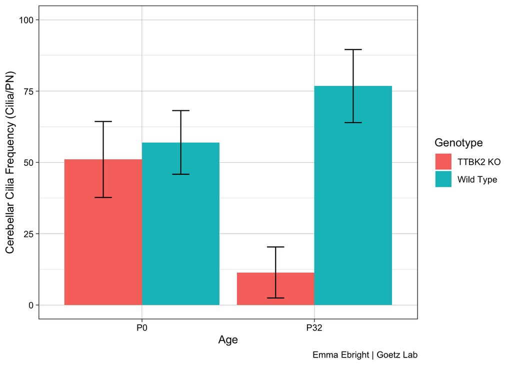

### Cilia Frequency By Folia

Because not much is known about Purkinje cells and cilia in the cerebellum, I separated out data by folia to calculate cilia frequency from both P0 and P32 datasets.

and combined them into one set for easy graphing:

```r
#combine P32 and P0
compare_p0p32_folia <- compare_folia_0%>%
  bind_rows(compare_folia_32)
head(compare_p0p32_folia)
```

```
## # A tibble: 6 × 9
##   image_id folia genotype_id genotype  num_pn num_cilia cilia_frequency Genotype
##   <chr>    <chr> <chr>       <chr>      <dbl>     <dbl>           <dbl> <chr>
## 1 9.1.1    I/II  Wild Type 1 TTBK2 fl…     92        70            76.1 Wild Ty…
## 2 9.i.a    I/II  Wild Type 1 TTBK2 fl…     86        42            48.8 Wild Ty…
## 3 9.i.a    I/II  Wild Type 1 TTBK2 fl…     67        35            52.2 Wild Ty…
## 4 5.ii.a   I/II  Wild Type 2 TTBK2 fl…    135        77            57.0 Wild Ty…
## 5 5.ii.a   I/II  Wild Type 2 TTBK2 fl…     87        59            67.8 Wild Ty…
## 6 5.ii.a   I/II  Wild Type 2 TTBK2 fl…     92        64            69.6 Wild Ty…
## # … with 1 more variable: Age <chr>
```

The graphs show that cilia frequency is once again depleted in KO conditions compared to WT, and that cilia frequency itself remains consistent throughout all folia in both WT and KO conditions. Cilia frequency in TTBK2 KO is greatly affected in P32 cerebellum compared to P0 cerebellum.

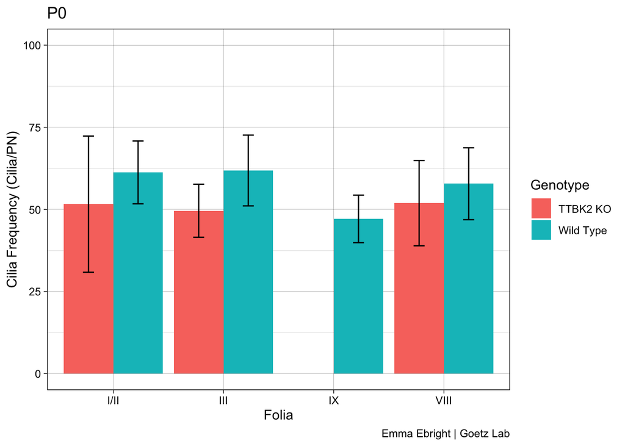

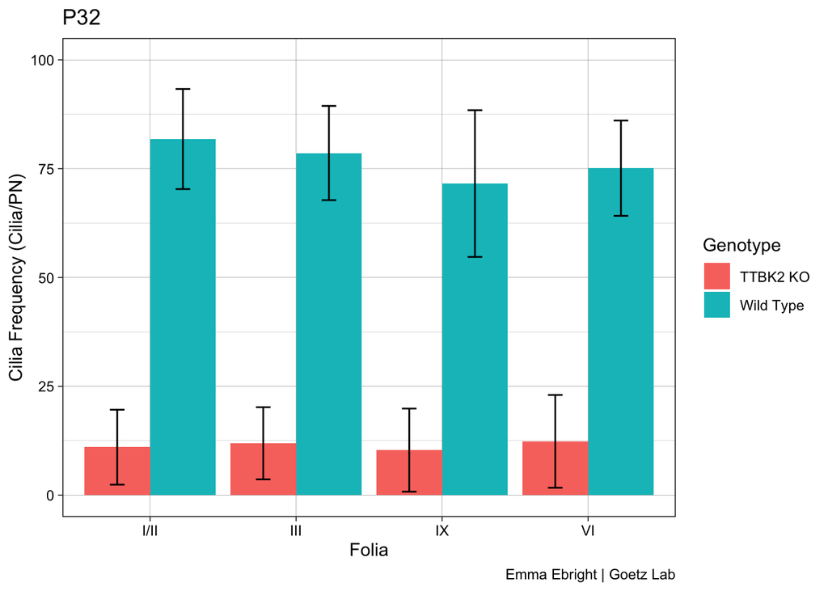

### Looking At Each Folia

My PI was interested in looking at specific Purkinje cell development in folia by age, so I took out individual folia data from my datasets to graph and compare each folia:

```r
p0p32folia_II_ <- compare_p0p32_folia%>%
  filter(grepl('I/II', folia))
p0p32folia_III_ <- compare_p0p32_folia%>%
  filter(grepl('III', folia))
p0p32folia_VI_ <- compare_p0p32_folia%>%
  filter(grepl('VI', folia))
p0p32folia_IX_ <- compare_p0p32_folia%>%
  filter(grepl('IX', folia))
```

[figure not shown]

### Future Directions

In addition to analyzing cilia frequency in Purkinje cells, we are interested in including more time points (P8, P20) to get a better look into cilia maintenance and disassembly during development. To get a good picture of cerebellar ciliation during embryogenesis, it would be interesting to look at cilia frequency in Purkinje precursors (staining for Olig2, FoxP2 expression) in various embryological stages.

### Thank You:

Emma Ebright (Goetz Lab) for helping dissect, section, stain, and image mouse brains to create this dataset. Devang Thakkar for being the GOAT and hopping on a Zoom at 4:37PM. My mom for telling me that I’m a “hacker” now.